# Introduction to TPLDA

## A simple example using the iris dataset

**1 The datatset:**

We will use the **iris** dataset, which gives measurements in centimeters of the following four variables: sepal length, sepal width, petal length, width length.

The response variable is the species of iris. Three species are consider:setosa, versicolor and virginica. The dataset contains 50 iris samples of each species.

```r
data(iris)
names(iris)
```

```
## [1] "Sepal.Length" "Sepal.Width"  "Petal.Length" "Petal.Width"
## [5] "Species"
```

```r
table(iris$Species)
```

```
##
##     setosa versicolor  virginica
##         50         50         50
```

**2. Data formatting:**

The TPLDA functions in *Functions_TPLDA.R* only deal with binary classification problem (for this moment). So we consider only the following two species: setosa and virgina. Moreover, the 50 versicolor samples are equally include in the setosa and the virginica group (in order to make the problem harder).

The data have to have the following format:

```r
#data<-iris[which(iris$Species=="setosa" | iris$Species=="versicolor"),c(5,1:4)]
data<-iris[,c(5,1:4)]
names(data)
```

```
## [1] "Species"      "Sepal.Length" "Sepal.Width"  "Petal.Length"
## [5] "Petal.Width"
```

```r
names(data)[1]<-"Y"
#data$Y<-as.factor(ifelse(data$Y=="setosa",1,0))
data$Y<-c(rep(1,75),rep(0,75))
```

We consider two groups of inputs :

- Group 1: sepal length and sepal width
- Group 2: petal length and petal width.

```r
group<-c(NA,1,1,2,2)
names(data)[-1]<-paste(names(data)[-1],"_G",group[-1],sep="")
names(data)
```

```
## [1] "Y"               "Sepal.Length_G1" "Sepal.Width_G1"  "Petal.Length_G2"
## [5] "Petal.Width_G2"
```

The dataset is divided into a training sample (2/3 of the data) and a validation sample (1/3 of the data).

```r
ind0 <- which(data$Y == "0")
ind1 <- which(data$Y == "1")
ind0_val<-sample(ind0, floor(length(ind0) * 1/3), F)
ind1_val<-sample(ind1, floor(length(ind1) * 1/3), F)
validation<-data[c(ind0_val,ind1_val),]
train<-data[setdiff(c(ind0,ind1),c(ind0_val,ind1_val)),]
table(validation$Y);dim(validation)
```

```
##
##  0  1
## 25 25
```

```
## [1] 50  5
```

```r
table(train$Y);dim(train)
```

```
##
##  0  1
## 50 50
```

```
## [1] 100   5
```

**3. Building a maximal TPLDA tree:**

We use the default values for the parameters i.e.:

- crit= 1 (the used impurity function is the Gini index)
- case_min = 3 (the minimum number of observations that must exist in a node in order for a split to be attempted)
- kfold = 3 (the minimum number of observations that must exist in a node in order for a split to be attempted)
- penalty=“No” (no penalty function is used in the splitting criterion.)

Since we want to assess the importance of the group, we set:

- group.importance= TRUE.

```r
source("Fonctions_TPLDA.R")
maximal_tree <-Tree_PLDA(train,group=group,grp.importance=TRUE)
print(maximal_tree$tree)
```

```
##    action  var lambda taille_groupe n_zero depth parent   n n_case
## 1       1    2  0.222             2      0     0   <NA> 100     50
## 2       1    2  0.222             2      0     1      1  41     38
## 3       1    2  0.222             2      0     1      1  59     12
## 4      -1 <NA>   <NA>          <NA>   <NA>     2      2  35     35
## 5       1    1  0.004             2      0     2      2   6      3
## 6       1    2    0.1             2      0     2      3  13      5
## 7       1    2  0.028             2      0     2      3  46      7
## 8      -1 <NA>   <NA>          <NA>   <NA>     3      5   4      3
## 9      -1 <NA>   <NA>          <NA>   <NA>     3      5   2      0
## 10     -1 <NA>   <NA>          <NA>   <NA>     3      6   4      3
## 11     -1 <NA>   <NA>          <NA>   <NA>     3      6   9      2
## 12      1    2  0.222             2      0     3      7   9      5
## 13     -1 <NA>   <NA>          <NA>   <NA>     3      7  37      2
## 14     -1 <NA>   <NA>          <NA>   <NA>     4     12   5      3
```

[output cut: 17 more lines]

We first build the sequence of subtree with the function *tree_seq_PLDA*.

```r
tree_seq<-tree_seq_PLDA(maximal_tree$tree)
#print(tree_seq)
```

Next, we select the subtree in the sequence that minimizes the classifiction error rate on the validation sample.

```r
error_validation<- impurete_plda(validation, tree_seq=tree_seq,treePLDA=maximal_tree)$impurete$Misclass
print(error_validation)
```

```
## [1] 0.5 0.2 0.2 0.2 0.2
```

```r
Final_tree<- tree_seq[[which.min(error_validation)]]
print(Final_tree)
```

```
##   action var lambda taille_groupe n_zero depth parent   n n_case n_noncase
## 1      1   2  0.222             2      0     0   <NA> 100     50        50
## 2     -1  NA  0.222             2      0     1      1  41     38         3
## 3     -1  NA  0.222             2      0     1      1  59     12        47
##   yhat yval   prob leave node
## 1 <NA>    1    0.5          1
## 2    1    1 0.9268     *    2
## 3    0    0 0.2034     *    3
```

**Group importance:**

```r
  importance<-rep(0,length(unique(group[!is.na(group)])))
for(j in unique(as.numeric(as.character(Final_tree$parent[!is.na(Final_tree$parent)])))){
      importance<-importance+as.numeric(as.character(maximal_tree$importance[[j]]))
    }
    importance<-importance*(100/max(importance))
    print(importance)
```

```
## [1]  67.75673 100.00000
```

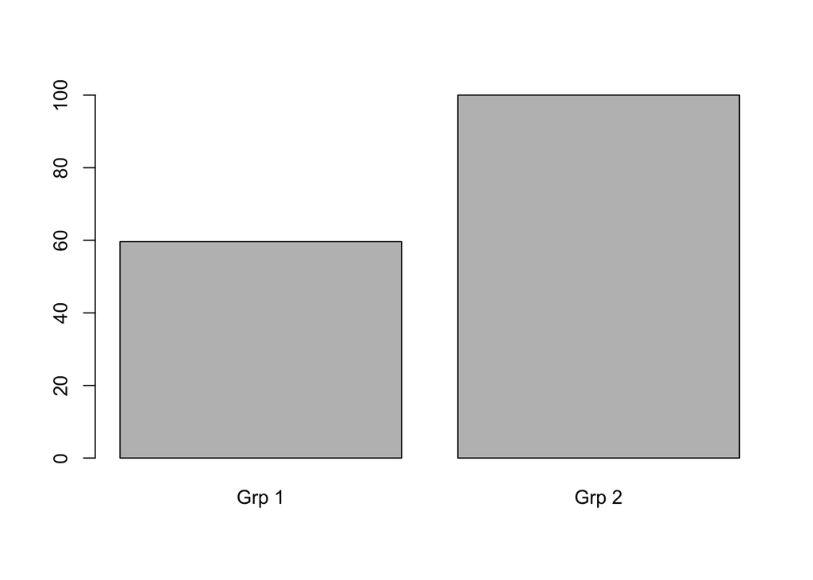

```r
importance<-group_importance(Final_tree,maximal_tree,group)
barplot(importance$importance_cor,names=c("Grp 1","Grp 2"))
```